# Using tidycensus

Maria Kamenetsky

January 2019

```r
library(tidycensus)
library(tidyverse)
```

There are several ways to load data into the `R` environment for analysis. Using the `tidycensus` package, we can directly querry the Census Bureau for data after obtainin a Census API key (http://api.census.gov/data/key_signup.html).

From the `tidycensus` package, we use the `census_api_key()` function and specify `install=TRUE` so that the API key is stored in the local `R` environment. To access the variables we want from the 2000 Census Summary File 3 (SF3) (https://www.census.gov/census2000/sumfile3.html). It should be noted that using `tidycensus`, we can also load ACS (American Community Survey) data as well as other census years.

```r
census_api_key("YOUR API KEY HERE", install=TRUE)
```

```r
vars <- load_variables(2000, "sf3", cache=TRUE)
```

To explore the variables, you can use the `View()` function to filter and explore data available to you.

```r
View(vars)
```

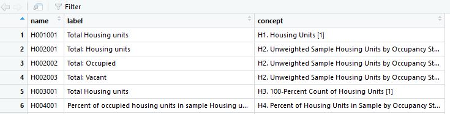

First six observations from loaded Census data

To download selected variables from the decennial Census, we use the `get_decennial()` function. We specify the geography to be “counties”, and the output to be “wide”, so each column will be a variable and each row will be a county in the United States. To load ACS data, we could use the `get_acs()` function. Below we only select some variables for illustration.

```r
pov <- get_decennial(geography="county",
                     variables=c(totpopn="P001001",
                         povty="P087001",
                         ag_male="P049003",
                         ag_female="P051045",
                         manu_male="P049007",
                         manu_female="P049034",
                         retail_male= "P049009",
                         retail_female="P049036"),
                     year=2000, output="wide")
str(pov)
```

```
## Classes 'tbl_df', 'tbl' and 'data.frame':    3219 obs. of  10 variables:
##  $ GEOID        : chr  "01001" "01003" "01005" "01007" ...
##  $ NAME         : chr  "Autauga County" "Baldwin County" "Barbour County" "Bibb County" ...
##  $ totpopn      : num  43671 140415 29038 20826 51024 ...
##  $ povty        : num  43377 138148 26239 19852 50499 ...
##  $ ag_male      : num  355 929 376 382 583 261 362 335 211 282 ...
##  $ ag_female    : num  96 237 49 65 114 99 56 81 30 88 ...
##  $ manu_male    : num  2378 5507 2067 1370 3041 ...
##  $ manu_female  : num  851 2388 1131 522 1391 ...
##  $ retail_male  : num  1297 4026 530 343 1319 ...
##  $ retail_female: num  1220 4913 541 448 1316 ...
```

```r
head(pov)
```

```
## # A tibble: 6 x 10
##   GEOID NAME  totpopn  povty ag_male ag_female manu_male manu_female
##   <chr> <chr>   <dbl>  <dbl>   <dbl>     <dbl>     <dbl>       <dbl>
## 1 01001 Auta~   43671  43377     355        96      2378         851
## 2 01003 Bald~  140415 138148     929       237      5507        2388
## 3 01005 Barb~   29038  26239     376        49      2067        1131
## 4 01007 Bibb~   20826  19852     382        65      1370         522
## 5 01009 Blou~   51024  50499     583       114      3041        1391
## 6 01011 Bull~   11714  10169     261        99       460         339
## # ... with 2 more variables: retail_male <dbl>, retail_female <dbl>
```